# Predicting Exercise Classe

Konstantinos Nakos

July 11, 2016

```r
        require(knitr)

        knitr::opts_chunk$set(echo = TRUE)

        opts_knit$set(root.dir = 'C:/Users/Konstantinos/Dropbox/R/Machine Learning/Prediction Assignment')

        library(caret)
        library(ggplot2)

        library(plyr)

        library(xtable)
        library(rattle)
        library(rpart.plot)

        #Disabling scientific notation
        options(scipen = 999)

        #Forcing two-digits printout for easier reading
        options(digits = 2)

        #Setting random seed to... 42
        #as it is the answer to... everything... :=)
        set.seed(42)
```

# Executive summary

The goal of this project is to build a model which will predict the manner in which people perform a particular exercise, namely the ‘Unilateral Dumbbell Biceps Curls’.

The dataset was provided by Velloso et al. (2013) and can be found here: http://groupware.les.inf.puc-rio.br/har . In the aforementioned website there is also additional information regarding the setup of the study and the specifics of data collection.

Through the development of a Random Forest model, we have been able to correctly predict 100% of the out-of-sample cases (testing dataset).

# Data

The specific data used for the analysis (as per course instructions) can be found below:

- Training: https://d396qusza40orc.cloudfront.net/predmachlearn/pml-training.csv
- Testing: https://d396qusza40orc.cloudfront.net/predmachlearn/pml-testing.csv

The code below downloads the data, if they are not already stored locally.

```r
        #Check if the directory exists, if not, create it
        if(!file.exists("Dataset")){
                dir.create("Dataset")
        }

        #Check if TRAINING file exists, if not, download it
        if(!file.exists("./Dataset/pml-training.csv")){
                download.file("https://d396qusza40orc.cloudfront.net/predmachlearn/pml-training.csv",
                              destfile = "./Dataset/pml-training.csv")
        }

        #Check if TESTING file exists, if not, download it
        if(!file.exists("./Dataset/pml-testing.csv")){
                download.file("https://d396qusza40orc.cloudfront.net/predmachlearn/pml-testing.csv",
                              destfile = "./Dataset/pml-testing.csv")
        }

        #Load the TRAINING dataset
        myTrainingDS <- read.csv2("./Dataset/pml-training.csv",
                                  sep = ",",
                                  stringsAsFactors = FALSE,
                                  na.strings = c("NA", "#DIV/0!",""),
                                  header = TRUE)

        #Load the TESTING dataset
        myTestingDS <- read.csv2("./Dataset/pml-testing.csv",
                                 sep = ",",
                                 stringsAsFactors = FALSE,
                                 na.strings = c("NA", "#DIV/0!",""),
                                 header = TRUE)
```

Once the data is loaded, we assign proper variable classes:

```r
        #Typo error correction
        colnames(myTrainingDS)[13] <- "kurtosis_pitch_belt"
        colnames(myTestingDS)[13] <- "kurtosis_pitch_belt"

        #Correcting data types

        ## TRAINING dataset
        myTrainingDS$user_name <- as.factor(myTrainingDS$user_name)
        myTrainingDS$cvtd_timestamp <- as.Date(myTrainingDS$cvtd_timestamp,
                                               "%d/%m/%Y")
        myTrainingDS$new_window <- as.factor(myTrainingDS$new_window)
        myTrainingDS$classe <- as.factor(myTrainingDS$classe)

        id <- c(8:ncol(myTrainingDS)-1)
        myTrainingDS[,id] <- as.numeric(unlist(myTrainingDS[,id]))

        ## TESTING dataset
        myTestingDS$user_name <- as.factor(myTestingDS$user_name)
        myTestingDS$cvtd_timestamp <- as.Date(myTestingDS$cvtd_timestamp,
                                              "%d/%m/%Y")
        myTestingDS$new_window <- as.factor(myTestingDS$new_window)

        id <- c(8:ncol(myTestingDS)-1)
        myTestingDS[,id] <- as.numeric(unlist(myTestingDS[,id]))

        ## Object 'id' no longer needed
        rm(id)
```

Next step is to treat missing values - current choice was to remove all variables with large number of missing values. Most of them however refer to ‘derivative’ measures e.g., belt pitch skewness and kurtosis and, as such, information lost seems minimal.

```r
        #Treatment of NA values
        #       Chosen to remove the columns with lots of NA
        #       In practice, this has to do with the removal of
        #               'derivative' values, such as skewness and kurtosis
        #               of the main variables, so there should be no
        #               significant loss of information - besides, these
        #               should be dealt with under own variable
        #               transformations, if needed.

        ## TRAINING Dataset
        tDS <- myTrainingDS[-c(1:7, 11:45, 49:83, 87:121, 125:159, 161)]

        ## TESTING Dataset
        vDS <- myTestingDS[-c(1:7, 11:45, 49:83, 87:121, 125:159)]
```

We next examine for the existence of (near)Zero Variance variables (candidates for removal). The analysis reveals that no such variables are currently included.

```r
        #Identification and elimination of (near-)Zero Variance predictors
        #       Last variable is 'classe2', which is not needed
        #       No (N)ZV's found given elimination of most columns
        tNZV <- nearZeroVar(tDS[,1:ncol(tDS)-1],
                            saveMetrics = TRUE,
                            names = TRUE)

        options(xtable.html.table.attributes =
          list(style=sprintf("style='%s'",
                             paste("border:0",
                                   "border-top: 1px solid grey",
                                   "border-bottom: 1px solid grey",
                                   sep="; "))))

        print(xtable(x = tNZV, caption = "Near Zero Value variables"),
              type = "html", caption.placement = "bottom")
```

Near Zero Value variables

|  | freqRatio | percentUnique | zeroVar | nzv |
| --- | --- | --- | --- | --- |
| roll_belt | 1.10 | 6.78 | FALSE | FALSE |
| pitch_belt | 1.04 | 9.38 | FALSE | FALSE |
| yaw_belt | 1.06 | 9.97 | FALSE | FALSE |
| roll_arm | 52.34 | 13.53 | FALSE | FALSE |
| pitch_arm | 87.26 | 15.73 | FALSE | FALSE |
| yaw_arm | 33.03 | 14.66 | FALSE | FALSE |
| roll_dumbbell | 1.02 | 84.21 | FALSE | FALSE |
| pitch_dumbbell | 2.28 | 81.74 | FALSE | FALSE |
| yaw_dumbbell | 1.13 | 83.48 | FALSE | FALSE |
| roll_forearm | 11.59 | 11.09 | FALSE | FALSE |
| pitch_forearm | 65.98 | 14.86 | FALSE | FALSE |
| yaw_forearm | 15.32 | 10.15 | FALSE | FALSE |

Finally, the (training) data are partitioned into two sets: the training set (60% of the data) and the testing set (remaining 40%) of the data, enabling model training and validation.

```r
        #Creating data partitions and training/validation sets
        inTrain <- createDataPartition(y = tDS$classe,
                                       p=0.60,
                                       list = FALSE)
        training <- tDS[inTrain,]
        testing <- tDS[-inTrain,]
```

# Training the models

For this exercise, two models have been selected: a partitioning/classification model as well as a Random Forest model.

The choice of the partitioning model has been due to its inherent simplicitly and interpretability: fundamentally, such models provide easy to follow (and most times intuitive also) decision rules.

However, for this particular setup, such a simplistic approach does not seem appropriate: indeed, the performance level of any particular physical exercise is a quite complex task. As such, we have chosen to train a Random Forest model.

## Classifications’ model

We initially train a partitioning model, as shown below:

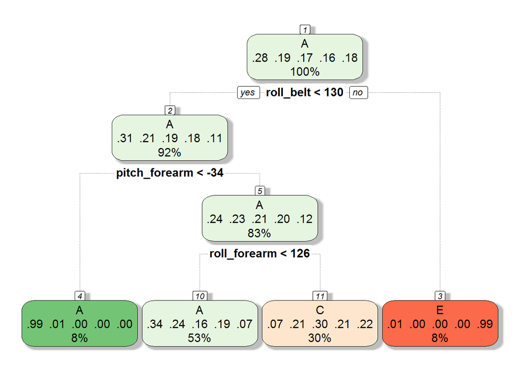

```r
        #Partitions classification
        modTR <- train(classe ~., data=training, method = "rpart")

        fancyRpartPlot(modTR$finalModel,
                       main = "",
                       sub = "")
```

```r
        ## Testing partitioning model (training dataset)
        y_TR <- predict(modTR$finalModel,
                        newdata = training,
                        type = "vector")
        y_TR <- mapvalues(y_TR,
                          from=c("1", "2", "3", "4", "5"),
                          to=c("A", "B", "C", "D", "E"))
        cm_TR <- suppressWarnings(confusionMatrix(y_TR, training$classe))

        ## Testing partitioning model (validation dataset)
        y_TR_valid <- predict(modTR$finalModel,
                              newdata = testing,
                              type = "vector")
        y_TR_valid <- mapvalues(y_TR_valid,
                                from=c("1", "2", "3", "4", "5"),
                                to=c("A", "B", "C", "D", "E"))
        cm_TR_valid <- suppressWarnings(confusionMatrix(y_TR_valid,
                                                        testing$classe))
```

Evidently, the resulting model tree generates an intuitive classification rule for classes “A” and “E”, however its overall accuracy is limited, both on the training and the validation dataset.

```r
        options(xtable.html.table.attributes =
          list(style=sprintf("style='%s'",
                             paste("border:0",
                                   "border-top: 1px solid grey",
                                   "border-bottom: 1px solid grey",
                                   sep="; "))))

        ### Classification table (training dataset)
        print(xtable(cm_TR$table,
               caption = "Partitioning classification table (training set)",
               auto = TRUE),
              type="html",
              caption.placement = "bottom")
```

Partitioning classification table (training set)

|  | A | B | C | D | E |
| --- | --- | --- | --- | --- | --- |
| A | 3106 | 1526 | 987 | 1192 | 421 |
| B | 0 | 0 | 0 | 0 | 0 |
| C | 234 | 753 | 1067 | 738 | 767 |
| D | 0 | 0 | 0 | 0 | 0 |
| E | 8 | 0 | 0 | 0 | 977 |

```r
        ### Accuracy statistic (training dataset)
        cm_TR$overall[1]
```

Accuracy 0.4373302

```r
        ### Classification table (validation dataset)
        print(xtable(cm_TR_valid$table,
                     caption = "Partitioning classification table (validation set)",
                     auto = TRUE),
              type = "html",
              caption.placement = "bottom")
```

Partitioning classification table (validation set)

|  | A | B | C | D | E |
| --- | --- | --- | --- | --- | --- |
| A | 2064 | 1046 | 671 | 809 | 314 |
| B | 0 | 0 | 0 | 0 | 0 |
| C | 162 | 472 | 697 | 477 | 474 |
| D | 0 | 0 | 0 | 0 | 0 |
| E | 6 | 0 | 0 | 0 | 654 |

```r
        ### Accuracy statistic (validation dataset)
        cm_TR_valid$overall[1]
```

Accuracy 0.4352536

## Random forest model

Given limited accuracy of the partitions model, we revert to a Random Forest model, as shown below:

```r
        #THIS IS A VERY SPECIAL CODE CHUNK
        #AS IT IS EXTREMELY NECESSARY TO BE CACHED...
        #EACH RUN TAKES APPROX 6 HRS ON MY LAPTOP
        #Random forest classification
        modRF <- train(classe ~ .,
                       data = training,
                       method = "rf",
                       prox=TRUE)
        ## Testing random forest classification model (validation dataset)
        y_RF_valid <- predict(modRF$finalModel, newdata = testing, type = "response")

        ## Random forest confusion matrix (validation dataset)
        cm_RF_valid <- confusionMatrix(y_RF_valid, testing$classe)

        ## Accuracy statistic (validation dataset)
        cm_RF_valid$overall[1]
```

Accuracy 0.9852154

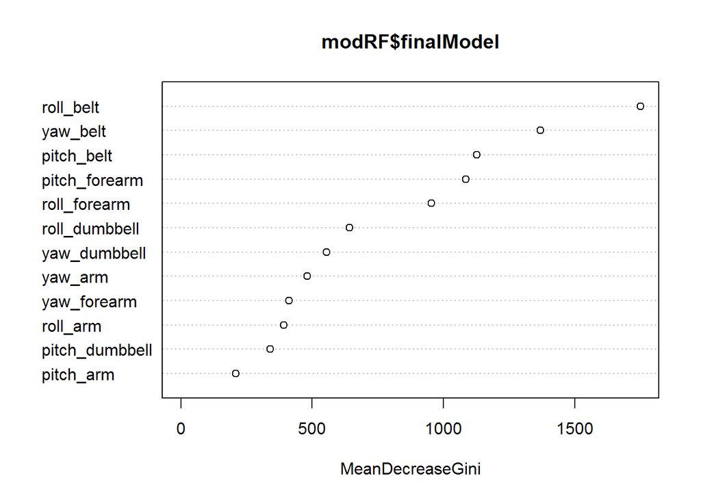

```r
        ## Variable importance chart
        varImpPlot(modRF$finalModel, type = 2)
```

```r
        options(xtable.html.table.attributes =
          list(style=sprintf("style='%s'",
                             paste("border:0",
                                   "border-top: 1px solid grey",
                                   "border-bottom: 1px solid grey",
                                   sep="; "))))

        ### Classification table (validation dataset)
        print(xtable(cm_RF_valid$table,
                     caption = "Random Forest classification table (validation set)",
                     auto = TRUE),
              type="html",
              caption.placement = "bottom")
```

Random Forest classification table (validation set)

|  | A | B | C | D | E |
| --- | --- | --- | --- | --- | --- |
| A | 2223 | 18 | 0 | 1 | 1 |
| B | 4 | 1473 | 8 | 2 | 10 |
| C | 1 | 24 | 1346 | 13 | 4 |
| D | 3 | 2 | 11 | 1269 | 8 |
| E | 1 | 1 | 3 | 1 | 1419 |

Evidently, the results obtained from the Random Forest model render it way more useful for prediction in this context. As such, we employ the final (trained) model for prediction.

# Predictions

Using the final Random Forest model, we predict exercise performance in the out-of sample dataset to be the following:

```r
        # Since Random forest accuracy is much higher than partitioning,
        #       we will use for predictions in the TESTING dataset
        # NOTE: THIS IS PERFORMED ONLY ONCE (NO FURTHER MODEL BUILDING)

        ## Testing random forest classification model (validation dataset)
        y_FINAL <- predict(modRF$finalModel, newdata = vDS, type = "response")

        print(y_FINAL)
```

1 2 3 4 5 6 7 8 9 10 11 12 13 14 15 16 17 18 19 20 B A B A A E D B A A B C B A E E A B B B Levels: A B C D E

Notably, these predictions have been used in the relevant quiz, rendering an impressive 100% out-of-sample accuracy.